# Simulations from Islam dataset, fold change 2

This document uses Fanny’s original simulation code in `islam_sims_fc2.Rmd` and has been adapted by Koen to adopt the new simulation framework.

```r
stopifnot(params$dataset %in% c("islam", "trapnell"))
stopifnot(as.numeric(params$n_samples) >= 2)
```

```python
import diffxpy.api as de
import pandas as pd
import numpy as np
# import scqtl
from diffxpy.api.stats import wald_test, wald_test_chisq
import diffxpy.api as de
import statsmodels.api as sm
```

```r
NCORES <- 8
registerDoParallel(NCORES)
register(DoparParam())
```

The goal of this document is to reproduce Figure 1 from our paper. A scRNA-seq dataset from Islam dataset is simulated using zingeR simulation framework. We evaluate the performance of different DE methods.

# Simulate scRNA-seq data

## Real dataset

The scRNA-seq simulation is based on the Islam mouse dataset, which compares 48 embryonic stem cells to 44 embryonic fibroblasts in mouse. Reference is Saiful Islam, Una Kjallquist, Annalena Moliner, Pawel Zajac, Jian-Bing Fan, Peter Lonnerberg, and Sten Linnarsson. Characterization of the single-cell transcriptional landscape by highly multiplex RNA-seq. Genome research.

## Simulating from zingeR framework

```r
if(params$dataset == 'islam') {
  #code from https://github.com/statOmics/zingeR/blob/master/vignettes/zingeRVignette_v2.Rmd
  data(islamEset, package = "zingeR")
  islamHlp=exprs(islamEset)[9:nrow(exprs(islamEset)),] #first 8 are spike-ins.
  cellType=pData(islamEset)[,"cellType"]
  paramsIslam = getDatasetMoMPositive(counts = islamHlp)
  save(paramsIslam, file="./paramsIslam.rda")

  # rename objects
  dataset_hlp = islamHlp
  dataset_params = paramsIslam
  dataset_var = cellType

  rm(islamHlp, paramsIslam, cellType)

} else if(params$dataset == 'trapnell') {
  # from 'preprocessTrapnellData.R'

  trapnellAssay72 <- readRDS("../../../datasets/GSE52529-GPL11154.rds")
  trapnellAssay72 = updateObject(trapnellAssay72)
  trapnellAssay <- readRDS("../../../datasets/GSE52529-GPL16791.rds")
  trapnellAssay = updateObject(trapnellAssay)
  trapnellAssay48 <- trapnellAssay[,colData(trapnellAssay)[,"characteristics_ch1.1"] == "hour post serum-switch: 48"]
  countsTrapnell72 <- round(assay(experiments(trapnellAssay72)$gene,"count"))
  id48=colData(trapnellAssay)[,"characteristics_ch1.1"] == "hour post serum-switch: 48"
  countsTrapnell48 <- round(assay(experiments(trapnellAssay)$gene[,id48],"count"))
  #wells containing debris
  debris72 = colData(trapnellAssay72)[,"characteristics_ch1.2"]=="debris: TRUE"
  debris48 = colData(trapnellAssay48)[,"characteristics_ch1.2"]=="debris: TRUE"
  #wells that did not contain one cell
  one72 = colData(trapnellAssay72)[,"characteristics_ch1.4"]!="cells in well: 1"
  one48 = colData(trapnellAssay48)[,"characteristics_ch1.4"]!="cells in well: 1"
  # remove
  countsTrapnell72 = countsTrapnell72[,(!debris72 & !one72)]
  countsTrapnell48 = countsTrapnell48[,(!debris48 & !one48)]
  countsTrapnell <- cbind(countsTrapnell48,countsTrapnell72)
  countsTrapnell <- countsTrapnell[rowSums(countsTrapnell>0)>9,] #expression in at least 10 out of 149 samples. Remains 24,576 genes and 149 samples.
  rm(trapnellAssay)

  timePoint=factor(c(rep(48,85),rep(72,64)))
  paramsTrapnell = getDatasetMoMPositive(counts = countsTrapnell)
  save(paramsTrapnell, file="./paramsTrapnell.rda")

  # rename objects
  dataset_hlp = countsTrapnell
  dataset_params = paramsTrapnell
  dataset_var = timePoint

  rm(countsTrapnell, paramsTrapnell, timePoint)
}
# load("./paramsIslam.rda")
```

```r
nSamples=as.numeric(params$n_samples)
grp=as.factor(rep(0:1, each = nSamples/2)) #two-group comparison
nTags=10000 #nr of features
set.seed(11)
DEind = sample(1:nTags,floor(nTags*.1),replace=FALSE) #10% DE
fcSim=(2 + rexp(length(DEind), rate = 1/2)) #fold changes
libSizes=sample(colSums(dataset_hlp),nSamples,replace=TRUE) #library sizes
sim_data <- NBsimSingleCell(foldDiff = fcSim, ind = DEind,
                                dataset = dataset_hlp, nTags = nTags,
                                group = grp,
                                verbose = TRUE, params = dataset_params,
                                lib.size = libSizes, normalizeLambda=TRUE)
sim_data$counts[1:5,1:5]
```

```
##      sample1 sample2 sample3 sample4 sample5
## ids1       0       0      13      46      31
## ids2      31      30       7      19       0
## ids3       0      22      25       0       0
## ids4       0       0       0       0       0
## ids5      43       0     193     214     172
```

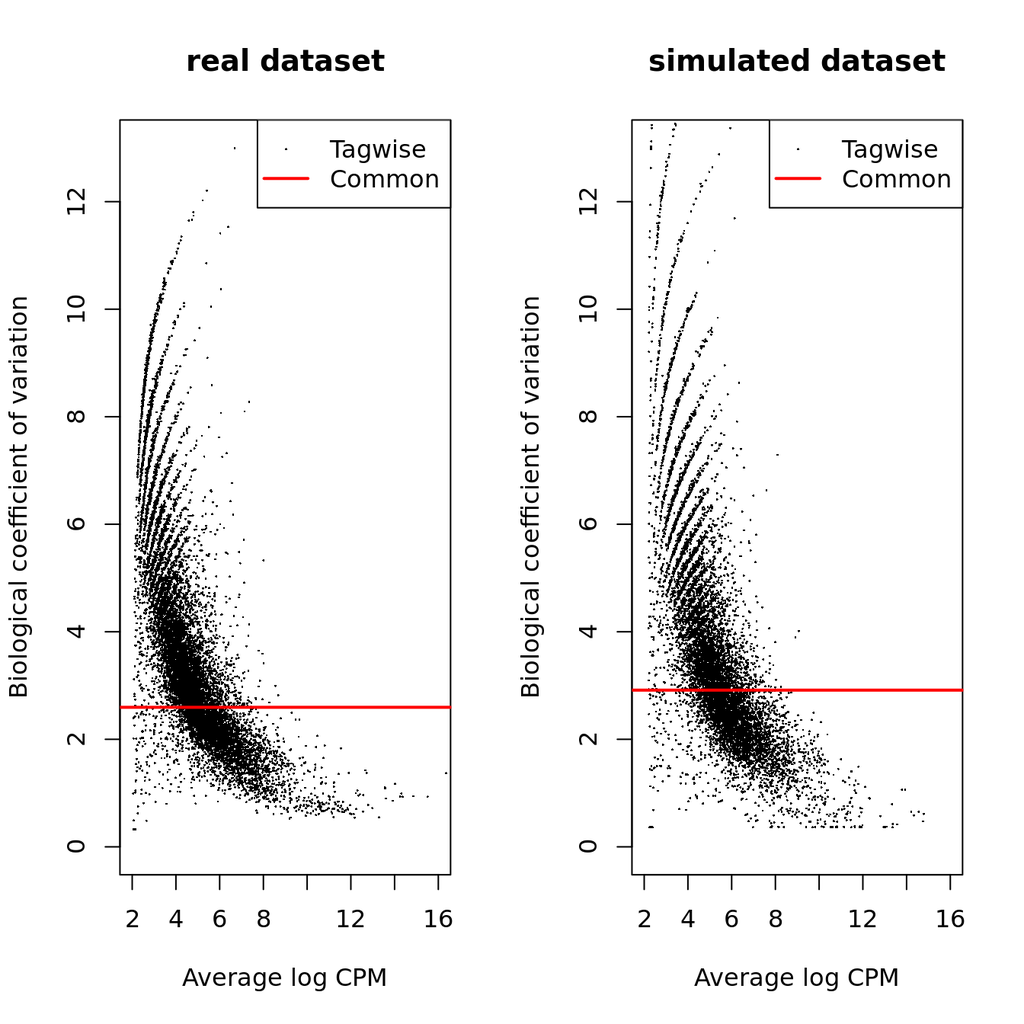

```r
# BCV plots
dOrig=suppressWarnings(edgeR::calcNormFactors(DGEList(dataset_hlp)))
dOrig=estimateGLMTagwiseDisp(estimateGLMCommonDisp(dOrig, design=model.matrix(~dataset_var), interval=c(0,10)),prior.df=0)

d=suppressWarnings(edgeR::calcNormFactors(DGEList(sim_data$counts)))
d=estimateGLMTagwiseDisp(estimateGLMCommonDisp(d, design=model.matrix(~grp), interval=c(0,10)),prior.df=0)

par(mfrow=c(1,2))
plotBCV(dOrig,ylim=c(0,13), xlim=c(2,16), main="real dataset")
plotBCV(d,ylim=c(0,13), xlim=c(2,16), main="simulated dataset")
```

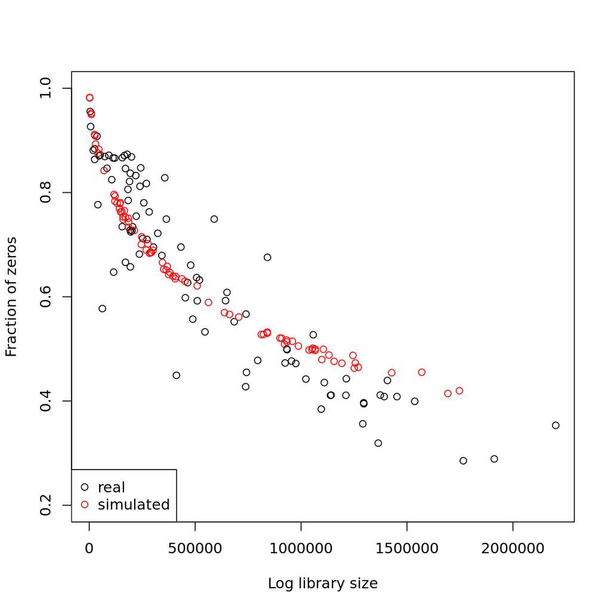

```r
par(mfrow=c(1,1))

# association of library size with zeros
plot(x=colSums(dataset_hlp), y=colMeans(dataset_hlp==0), xlab="Log library size", ylab="Fraction of zeros", ylim=c(0.2,1))
points(x=colSums(sim_data$counts), y=colMeans(sim_data$counts==0), col=2)
legend("bottomleft", c("real", "simulated"), col=1:2, pch=1)
```

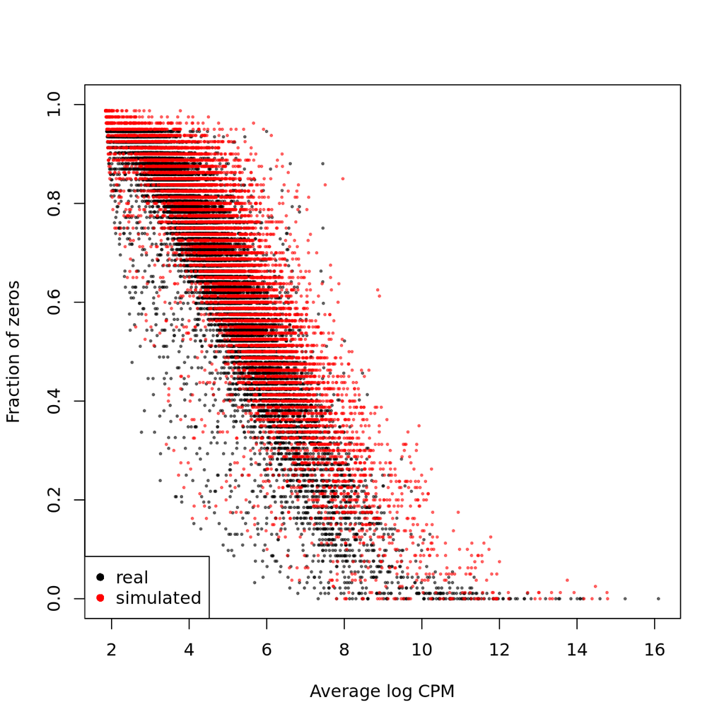

```r
# association of aveLogCPM with zeros
plot(x=edgeR::aveLogCPM(dataset_hlp), y=rowMeans(dataset_hlp==0), xlab="Average log CPM", ylab="Fraction of zeros", ylim=c(0,1), col=alpha(1,1/2), pch=19, cex=.3)
points(x=edgeR::aveLogCPM(sim_data$counts), y=rowMeans(sim_data$counts==0),col=alpha(2,1/2),pch=19,cex=.3)
legend("bottomleft", c("real", "simulated"), col=1:2, pch=16)
```

# Methods

## RNA-seq methods

### edgeR

```r
edgeR <- function(counts, group, ylim = NULL, xlim = NULL){
  d <- DGEList(counts)
  d <- suppressWarnings(edgeR::calcNormFactors(d))
  design <- model.matrix(~group)
  d <- estimateDisp(d, design)
  plotBCV(d, ylim = ylim, main = 'edgeR', xlim = xlim)
  fit <- glmFit(d,design)
  lrt <- glmLRT(fit, coef = 2)
  pval <- lrt$table$PValue
  padj <- p.adjust(pval, "BH")
  cbind(pval = pval, padj = padj)
}
```

```r
edger_ngenes <- function(counts, group, ylim = NULL, xlim = NULL){
  d <- DGEList(counts)
  d <- suppressWarnings(edgeR::calcNormFactors(d))
  cdr <- colSums(counts > 0)
  design <- model.matrix(~ group + cdr)
  d <- estimateDisp(d, design)
  plotBCV(d, ylim = ylim, main = 'edgeR', xlim = xlim)
  fit <- glmFit(d,design)
  lrt <- glmLRT(fit, coef = 2)
  pval <- lrt$table$PValue
  padj <- p.adjust(pval, "BH")
  cbind(pval = pval, padj = padj)
}
```

### DESeq2

```r
DESeq2 <- function(counts, group, ylim = NULL, xlim = NULL){
  colData <- data.frame(group = group)
  dse <- DESeqDataSetFromMatrix(countData=counts, colData=colData, design=~group)
  colData(dse)$group <- as.factor(colData(dse)$group)
  dse <- DESeq2::estimateSizeFactors(dse, type="poscounts")
  dse <- estimateDispersions(dse, minmu=1e-3)
  dse <- nbinomWaldTest(dse, minmu=1e-3, betaPrior=TRUE)
  rr <- results(dse)
  cbind(pval = rr$pvalue, padj = rr$padj)
}
```

### limma-voom

```r
limma <- function(counts, group, ylim = NULL, xlim = NULL){
    design <- model.matrix(~ group)
    nf <- suppressWarnings(edgeR::calcNormFactors(counts))
    y <- voom(counts, design, plot = FALSE, lib.size = colSums(counts) * nf)
    fit <- lmFit(y, design)
    fit <- eBayes(fit)
    tt <- topTable(fit, coef = 2, n = nrow(counts), sort.by = "none")
    pval <- tt$P.Value
    padj <- tt$adj.P.Val
    cbind(pval = pval, padj = padj)
}
```

## scRNA-seq methods

### scde

We encounter errors with the latest version of scde, as documented here: https://groups.google.com/forum/#!topic/singlecellstats/rbFUTOQ9wu4. We followed the guidelines suggested by the authors and work with version 1.99.2.

```r
scde <- function(counts, group, ylim=NULL, xlim=NULL){
  counts = matrix(as.integer(counts),nrow=nrow(counts),ncol=ncol(counts))
  if(is.null(colnames(counts))) colnames(counts)=paste0("sample",1:ncol(counts))
  require(scde)

  # calculate error models
  o.ifm <- scde.error.models(counts = counts, groups = group, n.cores = 1, threshold.segmentation = TRUE, save.crossfit.plots = FALSE, save.model.plots = FALSE, verbose = 0)
  # estimate gene expression prior
  o.prior <- scde.expression.prior(models = o.ifm, counts = counts, length.out = 400, show.plot = FALSE)
  # calculate differential expression
  ediff <- scde.expression.difference(o.ifm, counts, o.prior, groups  =  group, n.randomizations  =  150, n.cores  =  1, verbose  =  0)
  lfc <- ediff$mle
  pval=(1-pnorm(abs(ediff$Z)))*2
  padj=(1-pnorm(abs(ediff$cZ)))*2
  out = cbind(pval,padj,lfc)
  return(out)
}
```

### MAST

```r
### copied code from FPR_mocks.Rmd on September 14, 2017.
MAST <- function(counts, group, ylim = NULL, xlim = NULL){
  require(MAST)
  tpm <- counts*1e6/colSums(counts)
  tpm <- log2(tpm+1)
  sca <- FromMatrix(tpm,  cData=data.frame(group=group))
  #sca <- FromMatrix(counts,  cData=data.frame(group=group))

  # Adaptive thresholding from MAST vignette
  freq_expressed <- 0.2
  thres <- thresholdSCRNACountMatrix(assay(sca), nbins = 10, min_per_bin = 50, conditions = group)
  #par(mfrow=c(5,4))
  #plot(thres)
  assays(sca) <- list(thresh=thres$counts_threshold, tpm=assay(sca))
  expressed_genes <- freq(sca) > freq_expressed
  sca <- sca[expressed_genes,]

  ngeneson <- apply(counts,2,function(x) mean(x>0))
  CD <- colData(sca)
  CD$ngeneson <- ngeneson
  CD$cngeneson <- CD$ngeneson-mean(ngeneson)
  colData(sca) <- CD
  ## differential expression
  fit <- zlm(~ cngeneson + group , sca = sca)
  lrFit <- lrTest(fit, 'group')
  pval <- lrFit[, 'hurdle', 'Pr(>Chisq)']
  padj <- p.adjust(pval, method = "BH")

  ### MAST filtered the genes, so make a list that is consistent with the original count matrix.
  pvalAll = vector(length=nrow(counts))
  pvalAll[] = 1
  names(pvalAll)=rownames(counts)
  pvalAll[match(names(pval),names(pvalAll))] = pval

  padjAll = vector(length=nrow(counts))
  padjAll[] = 1
  names(padjAll)=rownames(counts)
  padjAll[match(names(padj),names(padjAll))] = padj

  out = cbind(pval = pvalAll, padj = padjAll, logfc = NA)
  return(out)
}
```

### NODES

```r
NODES <- function(counts, group, xlim, ylim){
  require(NODES)
  g=ifelse(group==0,"A","B")
  colnames(counts)=g
  normCounts=pQ(counts)
  res=NODES::NODES(data=normCounts,group=colnames(normCounts))
  pval=vector(length=nrow(counts))
  names(pval)=rownames(counts)
  pval[rownames(normCounts)]=res$Fisher
  pval[is.na(pval)]=1
  padj=p.adjust(pval,"BH")
  lfc=NA
  out=cbind(pval,padj,lfc)
  return(out)
}
```

### metagenomeSeq

```r
metagenomeSeq <- function(counts, group, xlim, ylim){
  require(metagenomeSeq)
  design <- model.matrix(~group)
  pheno <- AnnotatedDataFrame(data.frame(group=group))
  rownames(pheno) <- colnames(counts)
  p <- cumNormStatFast(counts)
  dat <- newMRexperiment(counts=counts, phenoData=pheno, featureData = NULL, libSize = colSums(counts), normFactors = metagenomeSeq::calcNormFactors(counts, p=p))
  fit <- fitZig(dat,design)
  lfc <- fit$eb$coefficients[,"group1"]
  pval <- fit$eb$p.value[,"group1"]
  padj <- p.adjust(pval)
  out <- cbind(pval,padj,lfc)
  return(out)
}
```

### Seurat

```r
Seurat <- function(counts, group, xlim=NULL, ylim=NULL){
    require(Seurat)
    seur = CreateSeuratObject(counts, project=paste0("cell",as.character(group)), display.progress = FALSE)
    res <- FindMarkers(seur, ident.1 = "cell0", ident.2 = "cell1", print.bar=FALSE)
    pval = res$p_val[match(rownames(counts),rownames(res))]
    padj = p.adjust(pval,"BH")
    out=cbind(pval,padj)
    return(out)
}
```

### DEsingle

```r
#https://github.com/miaozhun/DEsingle downloaded on November 20, 2017
DEsingle <- function(counts, group, xlim=NULL, ylim=NULL){
  require(DEsingle)
  res = DEsingle(counts=counts, group=group)
  pval = res[,"pvalue"]
  padj = res[,"pvalue.adj.FDR"]
  out=cbind(pval,padj)
  return(out)
}
```

### zingeR-edgeR

```r
zingeR_edgeR <- function(counts, group, ylim = NULL, xlim = NULL){
  #require(zingeR)
  d <- DGEList(counts)
  d <- suppressWarnings(edgeR::calcNormFactors(d))
  design <- model.matrix(~ group)
  weights <- zingeR::zeroWeightsLS(counts = d$counts, design = design, maxit = 300,
                           normalization = "TMM", verbose = F)
  d$weights <- weights
  d <- estimateDisp(d, design)
  plotBCV(d, ylim = ylim, main = 'zingeR', xlim = xlim)
  fit <- glmFit(d,design)
  lrt <- zinbwave::glmWeightedF(fit, coef = 2, independentFiltering = TRUE)
  cbind(pval = lrt$table$PValue, padj =lrt$table$padjFilter)
}
```

### zingeR-DESeq2

```r
zingeR_DESeq2 <- function(counts, group, ylim = NULL, xlim = NULL){
  #require(zingeR)
  colData <- data.frame(group = group)
  design <- model.matrix(~ group)
  dse <- DESeqDataSetFromMatrix(countData = counts, colData = colData,
                                design = ~group)
  weights <- zingeR::zeroWeightsLS(counts = counts, design = design, maxit = 300,
                           normalization = "DESeq2_poscounts", colData = colData,
                           designFormula = ~group, verbose = F)
  assays(dse)[["weights"]] <- weights
  dse <- DESeq2::estimateSizeFactors(dse, type="poscounts")
  dse <- estimateDispersions(dse)
  dse <- nbinomWaldTest(dse, betaPrior = TRUE, useT = TRUE,
                        df = rowSums(weights) - 2)
  rr <- results(dse)
  cbind(pval = rr$pvalue, padj = rr$padj)
}
```

## zinbwave

We compute the same weights as zingeR (i.e. posterior probabilities that a count belongs to the count component given that the count and library size is observed), but using the ZINB-WaVE estimation procedure. See more details here (http://www.biorxiv.org/content/early/2017/04/06/125112).

### zinbwave-edgeR

```r
zinbwave_edgeR <- function(counts, group, zinb, ylim = NULL, xlim = NULL, main = 'ZINB-WaVE'){
  d=DGEList(counts)
  d=suppressWarnings(edgeR::calcNormFactors(d))
  design=model.matrix(~group)
  weights <- computeObservationalWeights(zinb, d$counts)
  d$weights <- weights
  d=estimateDisp(d, design)
  plotBCV(d, ylim = ylim, main = main)
  fit=glmFit(d,design)
  lrt=glmWeightedF(fit,coef=2, independentFiltering = TRUE)
  cbind(pval = lrt$table$PValue, padj =lrt$table$padjFilter)
}
```

### zinbwave-DESeq2

```r
zinbwave_DESeq2 <- function(counts, group, zinb){
  colData=data.frame(group=group)
  design=model.matrix(~group)
  dse=DESeqDataSetFromMatrix(countData=counts, colData=colData, design=~group)
  weights <- computeObservationalWeights(zinb, counts(dse))
  assays(dse)[["weights"]]=weights
  dse = DESeq2::estimateSizeFactors(dse, type="poscounts")
  dse = estimateDispersions(dse, minmu=1e-3)
  dse <- nbinomWaldTest(dse, minmu=1e-3, betaPrior=TRUE, useT=TRUE, df=rowSums(weights)-2)
  res = results(dse)
  cbind(pval = res$pvalue, padj = res$padj)
}
```

### zinbwave-limma-voom

```r
zinbwave_limma <- function(counts, group, zinb){
  design <- model.matrix(~group)
  nf <- edgeR::calcNormFactors(counts)
  zeroWeights <- computeObservationalWeights(zinb, counts)
  y <- voom(counts, design, plot=FALSE, lib.size = colSums(counts)*nf,
            weights = zeroWeights)
  y$weights <- y$weights * zeroWeights
  fit <- lmFit(y, design, weights=y$weights)
  fit$df.residual <- rowSums(zeroWeights) - ncol(design)
  fit <- eBayes(fit)
  tt <- topTable(fit,coef=2,n=nrow(counts), sort.by = "none")
  pval <- tt$P.Value
  baseMean = unname(rowMeans(sweep(counts,2,nf,FUN="*")))
  hlp <- pvalueAdjustment_kvdb(baseMean=baseMean, pValue=pval)
  padj <- hlp$padj
  cbind(pval = pval, padj = padj)
}
```

## diffxpy

### wald test

```python
def wald_test(counts, group):
  test = de.test.wald(
    data=counts.values,
    formula_loc="~ 1 + group",
    factor_loc_totest="group",
    sample_description=pd.DataFrame().assign(group=group),
    batch_size=100,
    training_strategy="DEFAULT",
    dtype="float64",
    gene_names=counts.index
  )
  return pd.DataFrame().assign(
    pval=test.pval,
    padj=test.qval
  )

def lrt_test(counts, group):
  test = de.test.lrt(
    data=counts.values,
    # TODO check what's correct. This is even inconsistent within diffxpy.
    full_formula_scale="~ 1",
    full_formula_loc="~ 1 + group",
    reduced_formula_scale="~ 1",
    reduced_formula_loc="~ 1",
    sample_description=pd.DataFrame().assign(group=group),
    batch_size=100,
    training_strategy="DEFAULT",
    dtype="float64",
    gene_names=counts.index
  )

def wald_test_counts(counts, group):
  n_genes = np.sum(counts > 0, axis=1)
  test = de.test.wald(
    data=counts.values,
    formula_loc="~ group + n_genes",
    factor_loc_totest=["group"],
    coef_to_test="group",
    sample_description=pd.DataFrame().assign(group=pd.Categorical(group), n_genes=np.float64(n_genes.values)),
    batch_size=100,
    training_strategy="DEFAULT",
    dtype="float64",
    gene_names=counts.index
  )
  return pd.DataFrame().assign(
    pval=test.pval,
    padj=test.qval
  )

# def test_scqtl(counts, group):
#     umi = counts.values.T
#     num_samples = umi.shape[0]
#     size_factors = np.ones(len(group))
#     test = de.test.wald(
#         data=umi.astype(np.float64),
#         formula_loc="~ 1 + group",
#         factor_loc_totest="group",
#         sample_description=pd.DataFrame().assign(group=group),
#         batch_size=100,
#         training_strategy="DEFAULT",
#         dtype="float64",
#         size_factors=size_factors,
#         gene_names=counts.index
#     )
#     design = test.model_estim.input_data.design_loc
#     size_factor = size_factors.reshape(1, num_samples).T
#     onehot = np.ones((num_samples, 1))
#     init = scqtl.tf.fit(umi=umi.astype(np.float32),
#          onehot=onehot.astype(np.float32),
#          design=design.astype(np.float32),
#          size_factor=size_factor.astype(np.float32),
#          learning_rate=1e-3,
#          max_epochs=8000,
#           verbose=True
#     )
#     res = scqtl.tf.fit(umi=umi.astype(np.float32),
#          onehot=onehot.astype(np.float32),
#          design=design.astype(np.float32),
#          size_factor=size_factor.astype(np.float32),
#          learning_rate=1e-3,
#          max_epochs=8000,
#         warm_start=init[:3],
#           verbose=True
#     )
#     wald_zinb = wald_test(res[0][0, :], np.maximum(res[1][0, :], 1e-299))
#     return wald_zinb
```

```python
import warnings
import sys
from multiprocessing import Pool
warnings.filterwarnings('ignore')


def _fit_model(data, model_class):
    model = model_class.from_formula(
        "gene ~ 1 + group",
         data,
         missing='raise'
    )
    try:
        res = model.fit(
            method='nm',
            disp=False,
            maxiter=5000
        )
        test = res.wald_test("group[T.1]=0")
        return test.pvalue
    except:
        return np.nan


def fit_models(count_matrix, group, model_class):
    p = Pool(16)
    assert len(group) == count_matrix.shape[1]
    _pvals = []
    pvals = []
    for i in range(count_matrix.shape[0]):
        if not i % 200:
            sys.stdout.write("model {}\r".format(i))
            sys.stdout.flush()
        data = pd.DataFrame().assign(gene=count_matrix.values[i, :]).assign(group=group)
        _pvals.append(p.apply_async(_fit_model, (data, model_class)))
    for i, r in enumerate(_pvals):
        if not i % 200:
            sys.stdout.write("gene: {}\r".format(i))
            sys.stdout.flush()
        pvals.append(r.get())
    p.close()
    return np.array(pvals)
```

```r
diffxpy_wald = function(counts, group, ylim = NULL, xlim=NULL) {
  res = py$wald_test(as.data.frame(t(counts)), group)
}

diffxpy_lrt = function(counts, group, ylim = NULL, xlim=NULL) {
  res = py$lrt_test(as.data.frame(t(counts)), group)
}

diffxpy_wald_counts = function(counts, group, ylim = NULL, xlim=NULL) {
  res = py$wald_test_counts(as.data.frame(t(counts)), group)
}

# scqtl_wald = function(counts, group, ylim=NULL, xlim=NULL) {
#   pval = py$test_scqtl(as.data.frame(counts), group)
#   data.frame(pval=pval, padj=p.adjust(pval, method="BH"))
# }

statsmodels_nb = function(counts, group, ylim=NULL, xlim=NULL) {
  pval = py$fit_models(as.data.frame(counts), group, py$sm$NegativeBinomial)
  data.frame(pval=pval, padj=p.adjust(pval, method="BH"))
}

statsmodels_zip = function(counts, group, ylim=NULL, xlim=NULL) {
  pval = py$fit_models(as.data.frame(counts), group, py$sm$ZeroInflatedPoisson)
  data.frame(pval=pval, padj=p.adjust(pval, method="BH"))
}

statsmodels_zinb = function(counts, group, ylim=NULL, xlim=NULL) {
  pval = py$fit_models(as.data.frame(counts), group, py$sm$ZeroInflatedNegativeBinomialP)
  data.frame(pval=pval, padj=p.adjust(pval, method="BH"))
}
```

# Results

```r
core <- SummarizedExperiment(sim_data$counts,
                             colData = data.frame(grp = grp))
```

```r
zinb_c <- zinbFit(core, X = '~ grp', commondispersion = TRUE, epsilon=1e12)
save(zinb_c, file = 'zinb-common-disp-fc2-eps12.rda')
# load('zinb-common-disp-fc2-eps12.rda')
```

```r
zinb_g <- zinbFit(core, X = '~ grp', commondispersion = FALSE, epsilon=1e12)
save(zinb_g, file = 'zinb-genewise-disp-fc2.rda')
#load('zinb-genewise-disp-fc2.rda')
```

# Compare dispersion estimates

```r
counts = sim_data$counts
myfct = list(DESeq2 = DESeq2,
             edgeR = edgeR,
             limmavoom = limma,
             MAST = MAST
             # NODES = NODES,
             # scde = scde,
             # metagenomeSeq = metagenomeSeq
        )
# if we additionally load Seurat, too many packages are loaded and the DLL limit is reached. We ran Seurat in a separate session and will add it in this session.


par(mfrow = c(2,2))
ylim = c(0, 11)
xlim = c(0, 16)
res = lapply(names(myfct), function(fname){
  fct = myfct[[fname]]
  message(paste0("running ", fname))
  fct(counts = counts, group = grp, ylim = ylim, xlim = xlim)
})
```

```
## (-1e-10,0.353]   (0.353,1.48]    (1.48,2.35]    (2.35,3.53]    (3.53,5.13]
##       1.250673       1.250673       1.250673       1.250673       1.250673
##     (5.13,7.3]     (7.3,10.2]    (10.2,14.2]    (14.2,19.6]
##       3.277946       3.365603       7.057327       9.403185
```

```r
# load("seuratResIslam.rda")
# res[[8]] = seuratRes
# names(res)[8] = "Seurat"
#res[['ZINB-WaVE_DESeq2_common']] = zinbwave_DESeq2(counts, grp, zinb_c)
res[['ZINB-WaVE_edgeR_common']]  = zinbwave_edgeR(counts, grp, zinb_c, ylim=ylim, main = 'ZINB-WaVE, common dispersion', xlim = xlim)
#res[['ZINB-WaVE_limmavoom_common']]  = zinbwave_limma(counts, grp, zinb_c)
#res[['ZINB-WaVE_DESeq2_genewise']] = zinbwave_DESeq2(counts, grp, zinb_g)
#res[['ZINB-WaVE_edgeR_genewise']]  = zinbwave_edgeR(counts, grp, zinb_g, ylim=ylim, main = 'ZINB-WaVE, genewise dispersion', xlim = xlim)
#res[['ZINB-WaVE_limmavoom_genewise']]  = zinbwave_limma(counts, grp, zinb_g)
#par(mfrow = c(1,1))
res[["zingeR_edgeR"]] = zingeR_edgeR(counts=sim_data$counts, group=grp)
```

```
## converged.
```

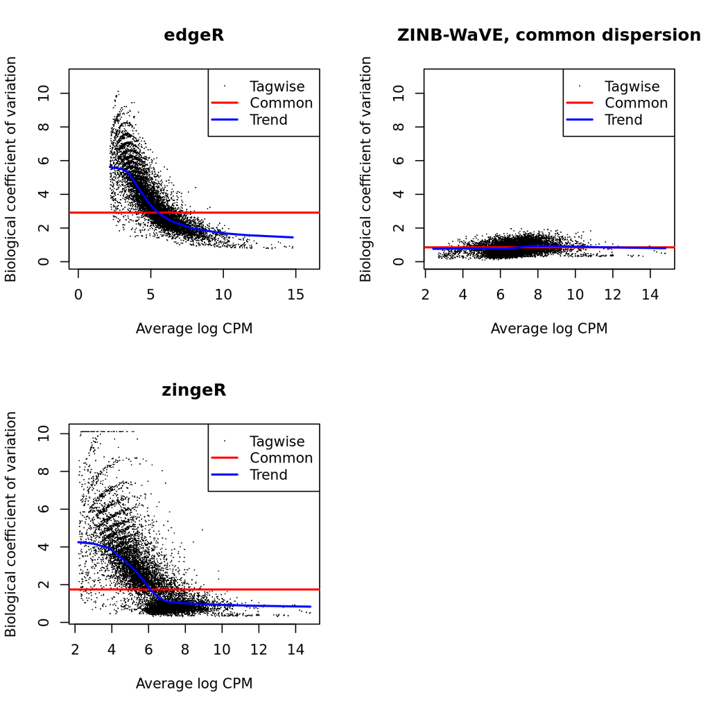

```r
#res[["zingeR_DESeq2"]] = zingeR_DESeq2(counts=sim_data$counts, group=grp)

save(res, file="./intermediate_res.rda")
# load("./intermediate_res.rda")
```

```r
res[["edger_ngenes"]] = edger_ngenes(counts=sim_data$counts, group=grp)
```

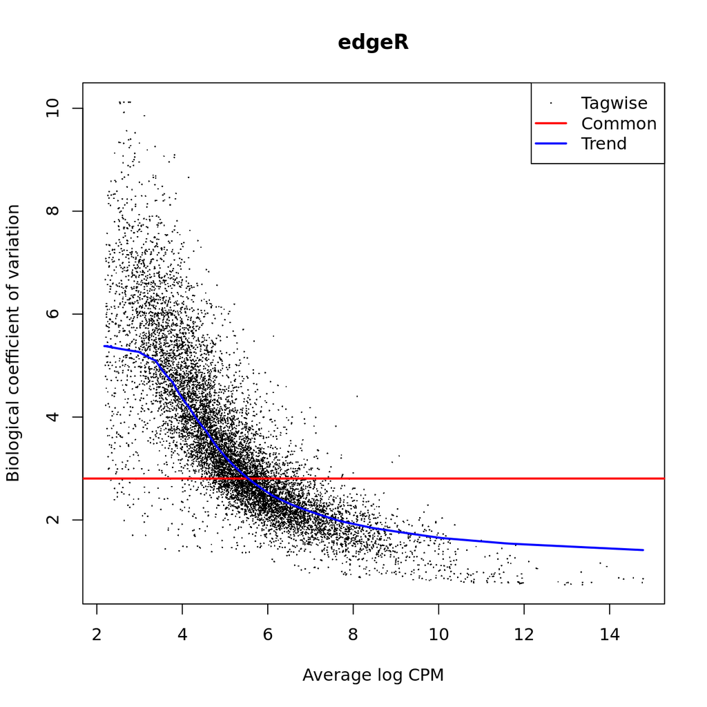

```r
res[["diffxpy_wald"]] = diffxpy_wald(counts=sim_data$counts, group=grp)
# Does not work, assertion error.
# res[["diffxpy_lrt"]] = diffxpy_lrt(counts=sim_data$counts, group=grp)
```

```r
# Does not work
# Error in py_call_impl(callable, dots$args, dots$keywords) :
# ValueError: constrained design matrix is not full rank: 79 80

# res[["diffxpy_wald_ngenes"]] = diffxpy_wald_counts(counts=sim_data$counts, group=grp)
invisible()
```

```r
res[["statsmodels_nb"]] = statsmodels_nb(counts=sim_data$counts, group=grp)
res[["statsmodels_zip"]] = statsmodels_zip(counts=sim_data$counts, group=grp)
res[["statsmodels_zinb"]] = statsmodels_zinb(counts=sim_data$counts, group=grp)
```

```r
# res[["scqtl"]] = scqtl_wald(counts=sim_data$counts, group=grp)
# res[["scqtl"]] = dplyr::rename(res[['scqtl']], padj=qval)
```

```r
res = lapply(res, as.data.frame)
names(res) = c(names(myfct), names(res)[5:length(res)])
for(k in 1:length(res)) res[[k]]$padj[is.na(res[[k]]$padj)] = 1
# load("../../results/resIslamFc2.rda")
save(res, file="resIslamFc2.tmp.rda")
```

## Compare weights estimates

```r
computeZinbwaveWeights <- function(zinb, counts){
  mu <- getMu(zinb)
  pi <- getPi(zinb)
  theta <- getTheta(zinb)
  theta_mat <- matrix(rep(theta, each = ncol(counts)), ncol = nrow(counts))
  nb_part <- dnbinom(t(counts), size = theta_mat, mu = mu)
  zinb_part <- pi * ( t(counts) == 0 ) + (1 - pi) *  nb_part
  zinbwg <- ( (1 - pi) * nb_part ) / zinb_part
  t(zinbwg)
}

zinbwave_c_weights <- computeZinbwaveWeights(zinb_c, counts)
zinbwave_g_weights <- computeZinbwaveWeights(zinb_g, counts)
```

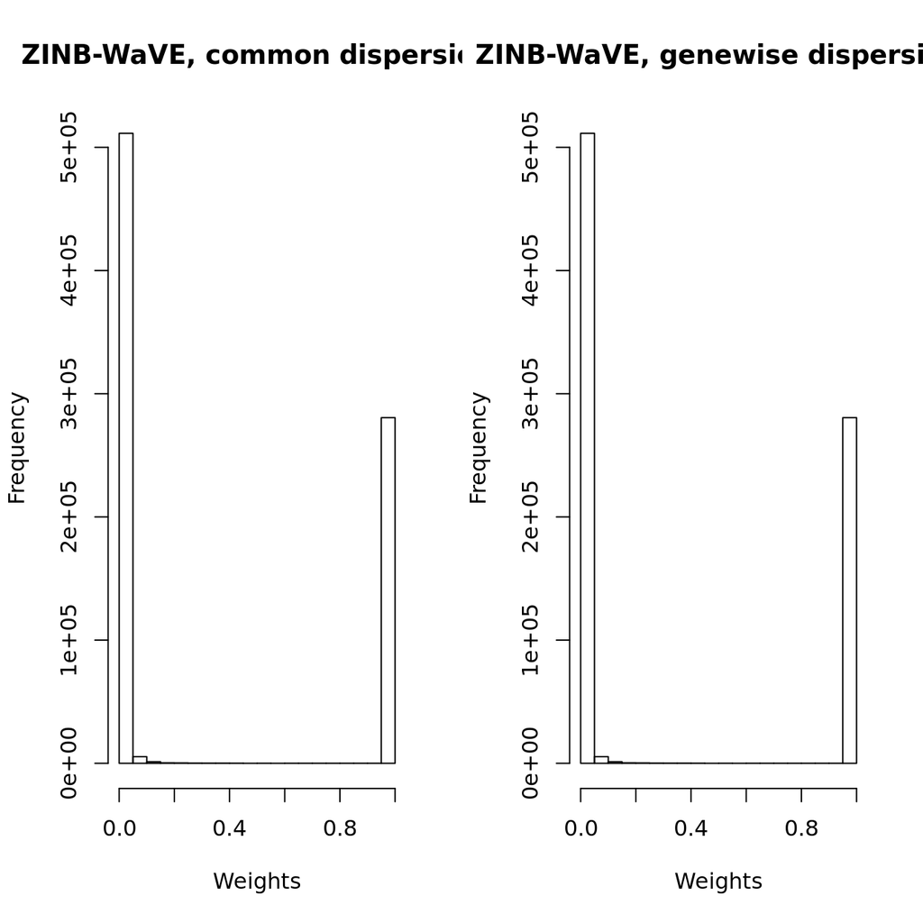

```r
par(mfrow=c(1,2))
#hist(zingeR_edgeR_weights, main='zingeR_edgeR', xlab = 'Weights')
#hist(zingeR_DESeq2_weights, main='zingeR_DESeq2', xlab = 'Weights')
hist(zinbwave_c_weights, main ='ZINB-WaVE, common dispersion', xlab = 'Weights')
hist(zinbwave_g_weights, main ='ZINB-WaVE, genewise dispersion', xlab = 'Weights')
```

```r
par(mfrow=c(1,1))
```

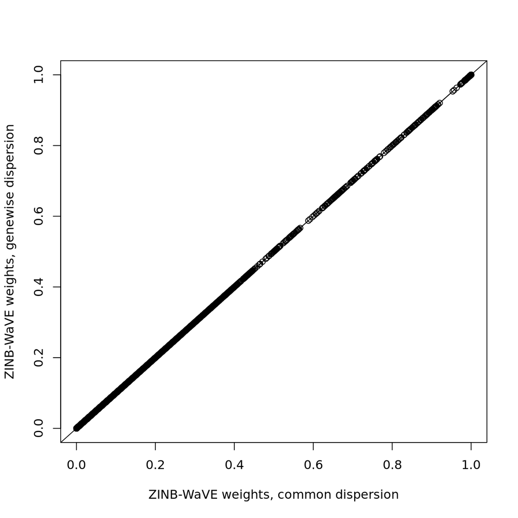

```r
qqplot(zinbwave_c_weights, zinbwave_g_weights, type = 'o',
       main = '',
       xlab = 'ZINB-WaVE weights, common dispersion',
       ylab = 'ZINB-WaVE weights, genewise dispersion')
abline(a=0,b=1)
```

## nDE, TPR, FDR (pvalue = 0.05)

```r
listRates = lapply(res, function(y){
  y = as.data.frame(y)
  nDE = sum(y[['padj']] <= 0.05, na.rm = TRUE)
  TPR = mean(sim_data$indDE %in% which( y$padj <= 0.05))
  FDR = mean(which(y$padj <= 0.05) %in% sim_data$indNonDE)
  c(nDE = nDE, TPR = TPR, FDR = FDR)
})

df = do.call(rbind, listRates)
df = as.data.frame(df)
df$Method = names(res)
df$nDE = as.integer(df$nDE)
df$TPR = round(df$TPR*100, 1)
df$FDR = round(df$FDR*100, 1)
df = df[,c('Method', 'nDE', 'TPR', 'FDR')]
colnames(df) = c('Method', 'nDE', 'TPR(%)', 'FDR(%)')
rownames(df) = NULL
kable(df)
```

| Method | nDE | TPR(%) | FDR(%) |
| --- | --- | --- | --- |
| DESeq2 | 122 | 12.2 | 0.0 |
| edgeR | 78 | 7.1 | 9.0 |
| limmavoom | 21 | 2.0 | 4.8 |
| MAST | 249 | 23.8 | 4.4 |
| ZINB-WaVE_edgeR_common | 578 | 53.6 | 7.3 |
| zingeR_edgeR | 376 | 36.0 | 4.3 |
| edger_ngenes | 99 | 9.3 | 6.1 |
| diffxpy_wald | 224 | 19.3 | 13.8 |
| statsmodels_nb | 85 | 7.7 | 9.4 |
| statsmodels_zip | 7676 | 94.1 | 87.7 |
| statsmodels_zinb | 753 | 55.4 | 26.4 |

## TPR vs FDR

```r
trueDE = rep(0, nTags)
trueDE[sim_data$indDE] = 1
```

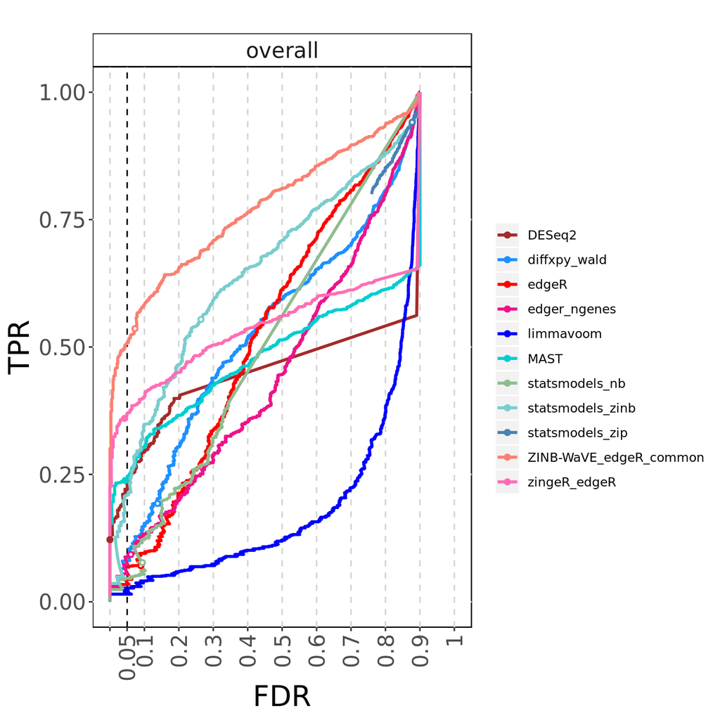

```r
#all methods
pp = COBRAData(pval = as.data.frame(do.call(cbind, lapply(res, '[[', 1))),
               padj = as.data.frame(do.call(cbind, lapply(res, '[[', 2))),
                truth = data.frame(status = trueDE))
cobraperf <- calculate_performance(pp, binary_truth = "status", thrs = 0.05)
colors=c(limmavoom="blue", "edger_ngenes2"="darkolivegreen4", "edger_ngenes"="deeppink2", edgeR="red", "ZINB-WaVE_edgeR_common"="salmon",  DESeq2="brown",  "ZINB-WaVE_DESeq2_genewise"="darkkhaki",  MAST="darkturquoise", metagenomeSeq="forestgreen", scde="grey", NODES="black",  Seurat="dodgerblue", "zingeR_edgeR"="hotpink1", zingeR_DESeq2="darkolivegreen4",
         diffxpy_wald="dodgerblue", statsmodels_nb='darkseagreen', statsmodels_zip='steelblue', statsmodels_zinb='darkslategray3')
#iCOBRA converts '-' to '.'. Redo this.
cobraNames = sort(names(cobraperf@overlap)[1:(ncol(cobraperf@overlap)-1)])
cobraNames = gsub(x=cobraNames, pattern=".", fixed=TRUE, replacement="-")
colsCobra=colors[match(cobraNames,names(colors))]
cobraplot <- prepare_data_for_plot(cobraperf, colorscheme=colsCobra)
save(cobraplot,file="cobraPlotIslamAllMethods.rda")
plot_fdrtprcurve(cobraplot, pointsize=1)
```

```r
# #only common disp ZINB-WaVE
# pvalDf = as.data.frame(do.call(cbind, lapply(res, '[[', 1)))
# padjDf = as.data.frame(do.call(cbind, lapply(res, '[[', 2)))
# pvalDfCommon = pvalDf[,-grep(x=colnames(pvalDf), pattern="genewise")]
# padjDfCommon = padjDf[,-grep(x=colnames(padjDf), pattern="genewise")]
# pp = COBRAData(pval = pvalDfCommon,
#                padj = padjDfCommon,
#                 truth = data.frame(status = trueDE))
# cobraperf <- calculate_performance(pp, binary_truth = "status", thrs = 0.05)
# colors=c(limmavoom="blue", "ZINB-WaVE_limmavoom_common"="steelblue", "ZINB-WaVE_limmavoom_genewise"="darkslategray3", edgeR="red", "ZINB-WaVE_edgeR_common"="salmon", "ZINB-WaVE_edgeR_genewise"="deeppink2",  DESeq2="brown",  "ZINB-WaVE_DESeq2_common"="darkseagreen", "ZINB-WaVE_DESeq2_genewise"="darkkhaki",  MAST="darkturquoise", metagenomeSeq="forestgreen", scde="grey", NODES="black",  Seurat="dodgerblue", "zingeR_edgeR"="hotpink1", zingeR_DESeq2="darkolivegreen4")
# #iCOBRA converts '-' to '.'. Redo this.
# cobraNames = sort(names(cobraperf@overlap)[1:(ncol(cobraperf@overlap)-1)])
# cobraNames = gsub(x=cobraNames, pattern=".", fixed=TRUE, replacement="-")
# colsCobra=colors[match(cobraNames,names(colors))]
# cobraplot <- prepare_data_for_plot(cobraperf, colorscheme=colsCobra)
# save(cobraplot,file="cobraplotIslam.rda")
# plot_fdrtprcurve(cobraplot, pointsize=1)
#
# #only common disp ZINB-WaVE, no ZINB-WaVE_limma-voom
# pvalDfCommon2 = pvalDfCommon[,-grep(x=colnames(pvalDfCommon), pattern="ZINB-WaVE_limmavoom")]
# padjDfCommon2 = padjDfCommon[,-grep(x=colnames(padjDfCommon), pattern="ZINB-WaVE_limmavoom")]
# pp = COBRAData(pval = pvalDfCommon2,
#                padj = padjDfCommon2,
#                 truth = data.frame(status = trueDE))
# cobraperf <- calculate_performance(pp, binary_truth = "status", thrs = 0.05)
# colors=c(limmavoom="blue", "ZINB-WaVE_limmavoom_common"="steelblue", "ZINB-WaVE_limmavoom_genewise"="darkslategray3", edgeR="red", "ZINB-WaVE_edgeR_common"="salmon", "ZINB-WaVE_edgeR_genewise"="deeppink2",  DESeq2="brown",  "ZINB-WaVE_DESeq2_common"="darkseagreen", "ZINB-WaVE_DESeq2_genewise"="darkkhaki",  MAST="darkturquoise", metagenomeSeq="forestgreen", scde="grey", NODES="black",  Seurat="dodgerblue", "zingeR_edgeR"="hotpink1", zingeR_DESeq2="darkolivegreen4", diffxpy_wald="dodgerblue")
# #iCOBRA converts '-' to '.'. Redo this.
# cobraNames = sort(names(cobraperf@overlap)[1:(ncol(cobraperf@overlap)-1)])
# cobraNames = gsub(x=cobraNames, pattern=".", fixed=TRUE, replacement="-")
# colsCobra=colors[match(cobraNames,names(colors))]
# cobraplot <- prepare_data_for_plot(cobraperf, colorscheme=colsCobra)
# #save(cobraplot,file="cobraplotIslamNoLimma.rda")
# plot_fdrtprcurve(cobraplot, pointsize=1) +xlab("FDP")



# res10 = res[1:10]
# names(res10) = gsub('_common', '', names(res10))
# pp = COBRAData(pval = as.data.frame(do.call(cbind, lapply(res10, '[[', 1))),
#                padj = as.data.frame(do.call(cbind, lapply(res10, '[[', 2))),
#                truth = data.frame(status = trueDE))
# cobraperf <- calculate_performance(pp, binary_truth = "status", thrs = 0.05)
#
# reds = brewer.pal(11, "RdYlGn")[1:3]
# blues = rev(brewer.pal(11, "RdYlBu"))[1:3]
# brown =  brewer.pal(8, "Dark2")[4]
# greens = rev(brewer.pal(11, "PiYG"))[1:3]
# mycol = c(blues[1], greens[1], reds[1], brown, blues[2], greens[2], reds[2],
#           blues[3], greens[3], reds[3], 'black')
# names(mycol) = c(names(res10), 'truth')
# names(cobraperf@overlap) = names(mycol)
# colsCobra <- mycol[match(sort(names(cobraperf@overlap)[1:(ncol(cobraperf@overlap)-1)]), names(mycol))]
# cobraplot <- prepare_data_for_plot(cobraperf, colorscheme = colsCobra,
#                                    facetted = FALSE)
#
# p1 <- plot_fdrtprcurve(cobraplot, plottype = c("curve", "points"), pointsize = 1,
#                        linewidth = .5, xaxisrange = c(0, .5)) +
#   theme(axis.text.x = element_text(size = 10),
#         axis.text.y = element_text(size = 10),
#         axis.title.x = element_text(size = 15),
#         axis.title.y = element_text(size = 15),
#         legend.text=element_text(size=7)) + theme(legend.position="none")
#
# orderLegend = c(2, 9, 6, 1, 8, 5, 3, 10, 7, 4)
# p2 <- plot_fdrtprcurve(cobraplot, plottype = c("curve", "points"), pointsize = 1,
#                        linewidth = .5, xaxisrange = c(0, .5)) +
#   theme(legend.text=element_text(size=7)) +
#   scale_color_manual(labels = names(colsCobra)[orderLegend],
#                      values = unname(colsCobra)[orderLegend],
#                      name = 'Method')
# legend <- get_legend(p2)
#
# #pdf("../../draftOverleaf/10963157vrrwqjqjdrnf/performanceIslamfc2.pdf")
# plot_grid(p1, legend, nrow = 1, ncol = 2, rel_widths = c(1, .4))
# #dev.off()
```

## Distribution of pvalues

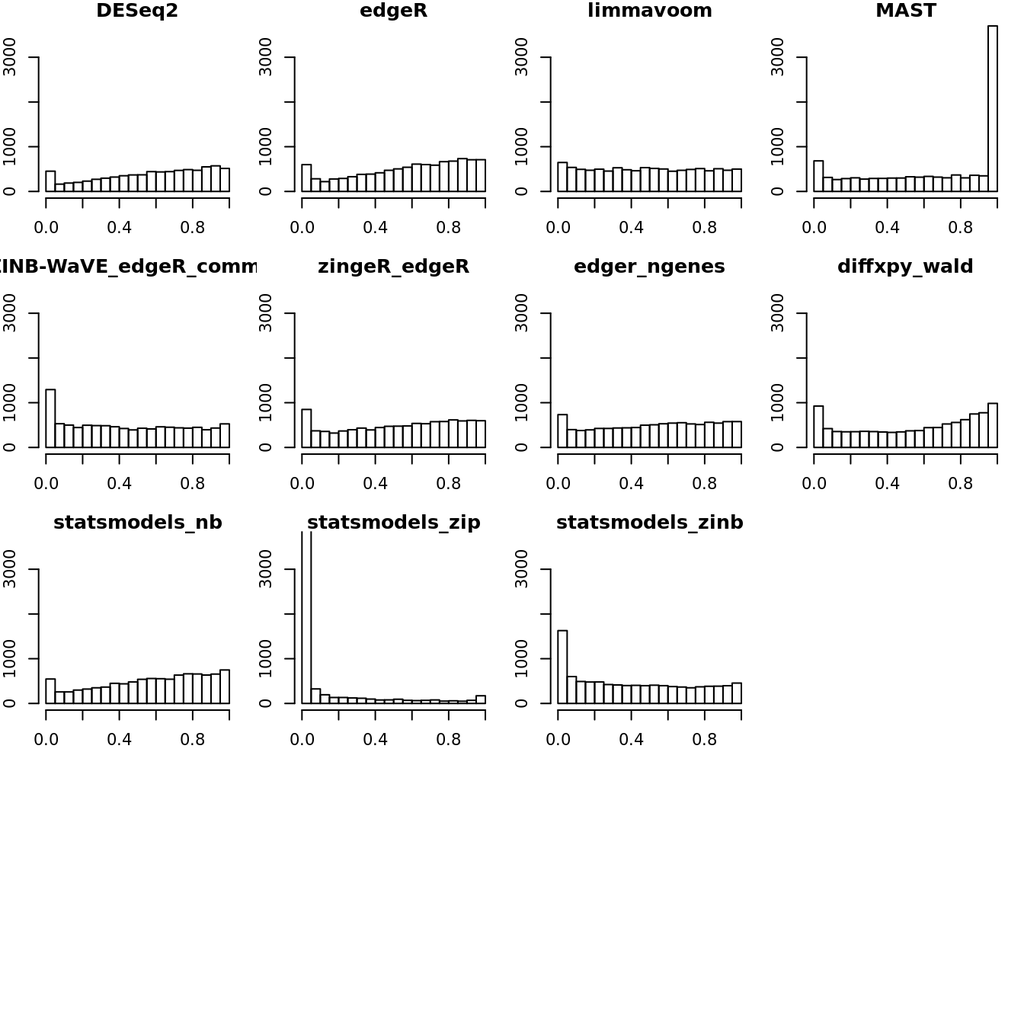

```r
# png("~/Dropbox/phdKoen/singleCell/zinbwaveZinger/plots2/pvalsIslamSim.png", width=9,height=9, units="in", res=300)
ylim = c(0, 3700)
par(mfrow = c(4,4), mar=c(3,2,1,1))
hist = lapply(1:length(res), function(i){
  hist(res[[i]][,'pval'], main = names(res)[i], ylim = ylim, xlab = 'pvalues', breaks=seq(0,1,0.05))
})
# dev.off()
```